# An introduction to **survClust package**

Arshi Arora  
Department of Epidemiology and Biostatistics, MSKCC

2022-08-04

# Contents

## 0.1 Overview

### 0.1.1 The tldr version

**survClust**$^1$ is an outcome weighted integrative supervised clustering algorithm, designed to classify patients according to their molecular as well as time-event or end point of interest. Until now, sub-typing in cancer biology has relied heavily upon clustering/mining of molecular data alone. We present classification of samples on molecular data supervised by time-event data like Overall Survival (OS), Progression Free Survival etc.

Below is the workflow of proposed survClust method:

`getDist` - Compute a weighted distance matrix based on outcome across given `m` data types. Standardization and accounting for non-overlapping samples is also accomplished in this step.

`combineDist` - Integrate `m` data types by averaging over `m` weighted distance matrices.

`survClust` and `cv.survclust` - Cluster integrated weighted distance matrices via `survClust`. Optimal `k` is estimated via cross-validation using `cv.survclust`. Cross-validated results are assessed over the following performance metrics - the **logrank statistic, standardized pooled within-cluster sum of squares (SPWSS)** and cluster solutions with **class size less than 5 samples**.

Note:

1. The input datatypes needs to be carefully pre-processed. See the data pre-processing section.
2. `cv.survclust` is a wrapper function that cross-validates and outputs cluster assignments. If you run without cross validation and just the commands on its own (`getDist`, `combineDist` and `survClust`), you are over-fitting!

All TCGA data has been downloaded from the TCGA pancancer paper[The Cancer Genome Atlas Research Network., Weinstein, J., Collisson, E. et al. The Cancer Genome Atlas Pan-Cancer analysis project. Nat Genet 45, 1113–1120 (2013).](https://doi.org/10.1038/ng.2764)

### 0.1.2 Bit more

## 0.2 Data and Pre-processing

The data and pre-processing steps are largely followed from iCluster manual by - iCluster (Mo Q, Shen R (2022). iClusterPlus: Integrative clustering of multi-type genomic data. R package version 1.32.0.). The pre-processing steps that we used in the manuscript are described here.

- Copy Number data was segmented using CBS$^4$ and reduced to non-redundant regions of alterations using the `CNregion` function in `iClusterPlus` with default epsilon of `0.001`, keeping in mind that the total numbers of features don’t exceed 10,000. See below and preprocessed data is provided with the package - `uvm_dat.Rds` Commented code goes over how we actually processed from the raw data.
- For DNA methylation, mRNA expression and miRNA expression, if a certain feature had more than 20% missing data, that feature was removed and remaining were used for analysis.
- For mRNA expression, we further removed genes having a mean expression lower than the threshold of mean expression of lower 10% quantile.
- Similarly, methylation probes with mean beta values < 0.1 and > 0.9 were discarded.
- For mutation data, we first filtered variants that were classified as `SILENT`. Secondly, genes harboring mutants in less than 1% of the samples were also removed. For our case study of UVM, we just removed singleton mutations. See below and preprocessed data is provided with the package - `uvm_dat.Rds`

```r
# DO NOT RUN. Use provided dataset
# Process mutation maf data
# maf = data.table::fread("mc3.v0.2.8.PUBLIC.maf.gz", header = T)
# maf_filter = maf %>% filter(FILTER == "PASS",
#                            Variant_Classification != "Silent")

# few lines of code in tidyR to convert maf to a binary file
# maf_binary <- maf_filter %>%
#   select(Tumor_Sample_Barcode, Hugo_Symbol) %>%
#   distinct() %>%
#   pivot_wider(names_from = "Hugo_Symbol",
#               values_from = 'Hugo_Symbol',
#               values_fill = 0, values_fn = function(x) 1)
# maf_binary$tcga_short = substr(maf_binary$Tumor_Sample_Barcode, 1, 12)

# Process clinical file
# tcga_clin = readxl::read_excel("TCGA-CDR-SupplementalTableS1.xlsx", sheet=1, col_names = TRUE)
#
# uvm_clin <- tcga_clin %>% filter(type == "UVM")
# uvm_maf_binary <- maf_binary %>%
#   filter(tcga_short %in% uvm_clin$bcr_patient_barcode) %>%
#   select(-Tumor_Sample_Barcode)
# rnames = uvm_maf_binary$tcga_short
#
# uvm_maf = uvm_maf_binary %>% select(-tcga_short) %>%
#   apply(., 2, as.numeric)

# Remove singletons
# gene_sum = apply(uvm_maf,2,sum)
# idx = which(gene_sum > 1)
#
# uvm_maf = uvm_maf[,idx]
# rownames(uvm_maf) = rnames
#

# uvm_survdat = uvm_clin %>% select(OS.time, OS) %>%
#   apply(., 2, as.numeric)
#
# rownames(uvm_survdat) = uvm_clin$bcr_patient_barcode

# process CN
# library(cluster)#pam function for derive medoid
# library(GenomicRanges) #interval overlap to remove CNV
# library(iClusterPlus)
#
# seg = read.delim(file="broad.mit.edu_PANCAN_Genome_Wide_SNP_6_whitelisted.seg", header=T,sep="\t", as.is=T)
#
# pp = substr(seg$Sample,13,16)
# seg.idx = c(grep("-01A",pp),grep("-01B",pp),grep("-03A",pp))
# only take tumors
# seg.idx = c(grep("-01A",pp),grep("-01B",pp))
# seg= seg[seg.idx,]

# seg$Sample= substr(seg[,1],1,12)
#
# uvm_seg = seg[seg$Sample %in% uvm_clin$bcr_patient_barcode,]

# colnames(uvm_seg)=c("Sample", "Chromosome", "Start", "End", "Num_Probes", "Segment_Mean")
# pass epsillon as 0.001 default or user
# reducedMseg=CNregions(ss_seg,epsilon=0.001,adaptive=F,rmCNV=F, cnv=NULL, frac.overlap=0.5, rmSmallseg=T, nProbes=75)

#uvm_dat <- list(uvm_mut = uvm_maf, uvm_cn = uvm_seg)

load("../data/uvm_dat.Rdata")

names(uvm_dat)
```

```
#> [1] "uvm_mut" "uvm_cn"
```

```r
uvm_dat$uvm_mut[1:5,1:5]
```

```
#>              RYR2 OBSCN TTN DNAH17 PLCB4
#> TCGA-RZ-AB0B    0     0   0      0     0
#> TCGA-V3-A9ZX    0     0   0      0     0
#> TCGA-V3-A9ZY    0     0   0      0     0
#> TCGA-V4-A9E5    0     0   0      0     0
#> TCGA-V4-A9E7    0     0   0      0     0
```

```r
uvm_dat$uvm_cn[1:5,1:5]
```

```
#>              chr1.3218610-4658538 chr1.4658538-4735056 chr1.4735056-4735908
#> TCGA-RZ-AB0B              -0.3696              -0.3696              -0.3696
#> TCGA-V3-A9ZX               0.0366               0.0366               0.0366
#> TCGA-V3-A9ZY              -0.0373              -0.0373              -0.0373
#> TCGA-V4-A9E5              -0.0614              -0.0614              -0.0614
#> TCGA-V4-A9E7              -1.0061              -1.0061              -1.0061
#>              chr1.4735908-4736456 chr1.4736456-6876455
#> TCGA-RZ-AB0B              -0.3696              -0.3696
#> TCGA-V3-A9ZX               0.0366               0.0366
#> TCGA-V3-A9ZY              -0.0373              -0.0373
#> TCGA-V4-A9E5              -0.0614              -0.0614
#> TCGA-V4-A9E7              -0.8835              -0.8835
```

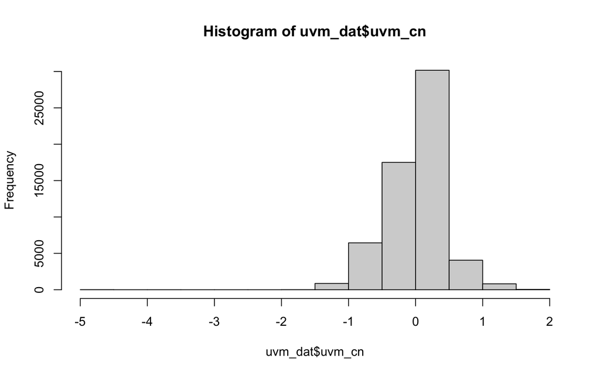

```r
hist(uvm_dat$uvm_cn)
```

```r
#uvm_survdat = load("../data/uvm_survdat.Rdata")
#head(uvm_survdat)
```

## 0.3 Supervised integrative cluster analysis

### 0.3.1 UVM data

### 0.3.2 simulation example

### 0.3.3 Bonus - UVM mutation data alone

## 0.4 Picking k

## 0.5 Results

[figure not shown]

[figure not shown]

```r
plot(1:10)
plot(10:1)
```

```
output:
  rmarkdown::html_vignette:
    fig_caption: yes
```

## 0.6 More Examples

[output not shown]